# Dataset5

```python
 !pip install pandas matplotlib numpy
 import pandas as pd
```

I used the sama dataset that I used for homework 4, but this time I used all 200 rows. However, as it's too many values, I wrote a code that will choose 30 random out of the 200.

```python
df = pd.read_csv("Dataset5.csv")
df.sample(n=30, random_state=42)
```

|  | student_id | hours_studied | sleep_hours | attendance_percent | previous_scores | exam_score |
| --- | --- | --- | --- | --- | --- | --- |
| 95 | S096 | 5.2 | 6.8 | 84.0 | 43 | 28.7 |
| 15 | S016 | 7.0 | 9.0 | 51.2 | 41 | 34.1 |
| 30 | S031 | 9.9 | 4.4 | 55.3 | 67 | 34.5 |
| 158 | S159 | 3.5 | 4.5 | 89.1 | 78 | 29.5 |
| 128 | S129 | 10.7 | 8.0 | 51.0 | 68 | 36.1 |
| 115 | S116 | 10.6 | 8.4 | 91.6 | 55 | 46.4 |
| 69 | S070 | 3.9 | 4.0 | 53.2 | 59 | 23.9 |
| 170 | S171 | 11.3 | 6.7 | 85.4 | 83 | 45.3 |
| 174 | S175 | 9.9 | 5.8 | 63.5 | 90 | 44.8 |
| 45 | S046 | 3.6 | 7.6 | 80.6 | 47 | 31.8 |
| 66 | S067 | 3.5 | 7.1 | 61.6 | 54 | 21.7 |
| 182 | S183 | 11.8 | 5.5 | 91.5 | 74 | 44.1 |
| 165 | S166 | 1.8 | 6.9 | 91.1 | 58 | 30.1 |
| 78 | S079 | 3.9 | 5.4 | 92.8 | 58 | 26.5 |
| 186 | S187 | 10.5 | 4.6 | 73.2 | 57 | 36.2 |
| 177 | S178 | 5.7 | 5.7 | 74.2 | 82 | 31.0 |
| 56 | S057 | 2.9 | 4.4 | 88.3 | 86 | 35.2 |
| 152 | S153 | 5.8 | 8.7 | 55.1 | 44 | 27.7 |
| 82 | S083 | 7.4 | 7.2 | 67.6 | 95 | 39.8 |
| 68 | S069 | 4.5 | 7.3 | 85.3 | 51 | 33.5 |
| 124 | S125 | 1.0 | 4.1 | 82.6 | 54 | 21.2 |
| 16 | S017 | 3.4 | 6.8 | 62.2 | 45 | 28.9 |
| 148 | S149 | 3.2 | 7.2 | 85.8 | 50 | 26.4 |
| 93 | S094 | 5.6 | 5.3 | 51.5 | 61 | 29.1 |
| 65 | S066 | 9.5 | 7.5 | 56.9 | 58 | 36.7 |
| 60 | S061 | 11.9 | 8.4 | 53.9 | 78 | 48.6 |
| 84 | S085 | 5.4 | 6.4 | 92.7 | 71 | 38.0 |
| 67 | S068 | 1.4 | 8.9 | 84.7 | 63 | 32.2 |
| 125 | S126 | 4.6 | 7.7 | 87.7 | 89 | 38.6 |
| 132 | S133 | 10.7 | 7.9 | 78.2 | 77 | 45.7 |

```python
df=df.sample(n=30, random_state=42)
df.head()       #first rows
df.describe()   #statistics
```

|  | hours_studied | sleep_hours | attendance_percent | previous_scores | exam_score |
| --- | --- | --- | --- | --- | --- |
| count | 30.000000 | 30.000000 | 30.000000 | 30.000000 | 30.000000 |
| mean | 6.336667 | 6.606667 | 74.060000 | 64.533333 | 34.210000 |
| std | 3.448886 | 1.522007 | 15.328711 | 15.553541 | 7.519187 |
| min | 1.000000 | 4.000000 | 51.000000 | 41.000000 | 21.200000 |
| 25% | 3.525000 | 5.425000 | 58.075000 | 54.000000 | 28.950000 |
| 50% | 5.500000 | 6.850000 | 79.400000 | 60.000000 | 33.800000 |
| 75% | 9.900000 | 7.675000 | 87.225000 | 77.750000 | 38.450000 |
| max | 11.900000 | 9.000000 | 92.800000 | 95.000000 | 48.600000 |

I created a bar chart to show each students' attendance rate. Among these 30 people, more than half of the people had an attendance rate of more than 60%.

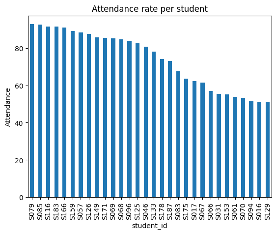

```python
import matplotlib.pyplot as plt

program_points = df.groupby("student_id")["attendance_percent"].mean().sort_values(ascending=False)
program_points
program_points.plot(kind="bar")
plt.title("Attendance rate per student")
plt.ylabel("Attendance")
plt.show()
```

```
<function matplotlib.pyplot.show(close=None, block=None)>
```

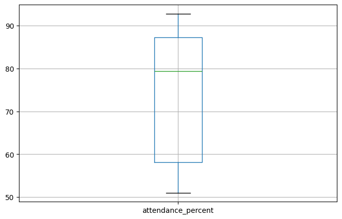

```python
plt.figure(figsize=(8,5))
df[["attendance_percent"]].boxplot()
plt.show
```

I created a bar chart showing how many hours each student slept. The chart shows that roughly 1/3 of the 30 students slpet less than 6 hours. There were only a few students who slept more than 8 hours.

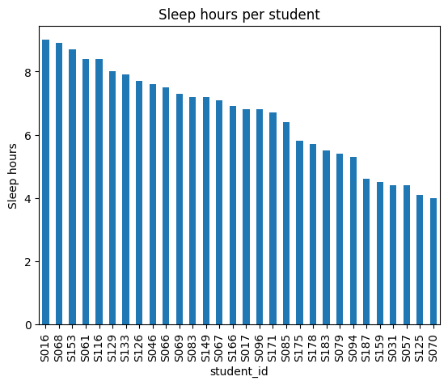

```python
import matplotlib.pyplot as plt

program_points = df.groupby("student_id")["sleep_hours"].mean().sort_values(ascending=False)
program_points
program_points.plot(kind="bar")
plt.title("Sleep hours per student")
plt.ylabel("Sleep hours")
plt.show()
```

I created a pie chart for sleep hour distribution. Many people slept between 6-8 hours, but almost as much slept only 4-6 hours.

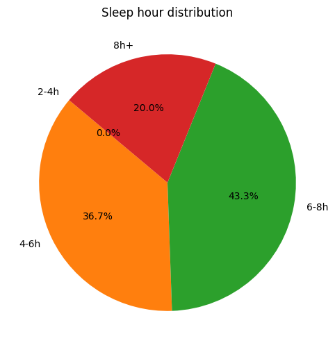

```python
import pandas as pd
import numpy as np
import matplotlib.pyplot as plt

hours_bins = [2, 4, 6, 8, np.inf]
hours_labels = ["2-4h", "4-6h", "6-8h", "8h+"]
df["sleep_band"] = pd.cut(df["sleep_hours"].clip(lower=0),

  bins=hours_bins, labels=hours_labels, right=False, include_lowest=True)

counts = df["sleep_band"].value_counts().sort_index()
plt.figure(figsize=(6,6))
plt.pie(counts, labels=counts.index.astype(str), autopct="%1.1f%%", startangle=140)
plt.title("Sleep hour distribution")
plt.show()
```

```
<function matplotlib.pyplot.show(close=None, block=None)>
```

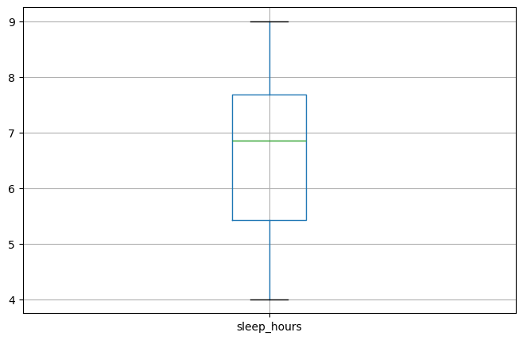

```python
plt.figure(figsize=(8,5))
df[["sleep_hours"]].boxplot()
plt.show
```

I created a bar chart showing study hours per student. Here I can see more variation - some people studied as much as 12 hours and some as little as an hour.

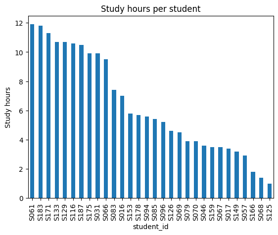

```python
import matplotlib.pyplot as plt

program_points = df.groupby("student_id")["hours_studied"].mean().sort_values(ascending=False)
program_points
program_points.plot(kind="bar")
plt.title("Study hours per student")
plt.ylabel("Study hours")
plt.show()
```

The piechart shows that 1/3 of students studied more than 8 hours. However another 1/3 studied less than 4 hours.

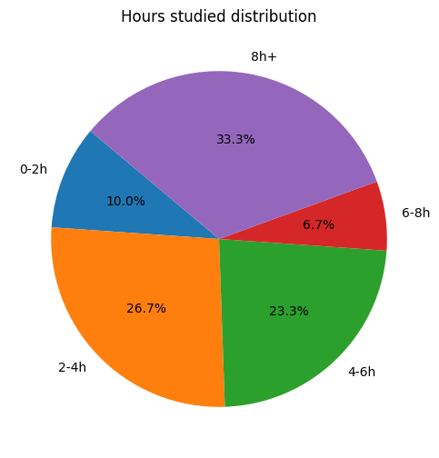

```python
hours_bins = [0, 2, 4, 6, 8, np.inf]
hours_labels = ["0-2h", "2-4h", "4-6h", "6-8h", "8h+"]
df["study_band"] = pd.cut(df["hours_studied"].clip(lower=0),
                          bins=hours_bins, labels=hours_labels, right=False, include_lowest=True)

counts = df["study_band"].value_counts().sort_index()
plt.figure(figsize=(6,6))
plt.pie(counts, labels=counts.index.astype(str), autopct="%1.1f%%", startangle=140)
plt.title("Hours studied distribution")
plt.show()
```

```
<function matplotlib.pyplot.show(close=None, block=None)>
```

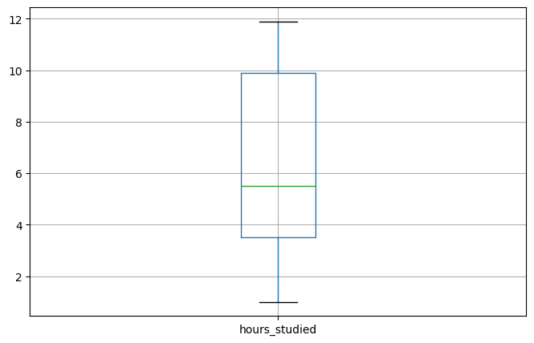

```python
plt.figure(figsize=(8,5))
df[["hours_studied"]].boxplot()
plt.show
```

For this scattered chart I used the whole dataset. There is no strong correlation between attendance rate and sleep hours. However students who slept around 4 hours had maximum attendance of roughly 80 percent.

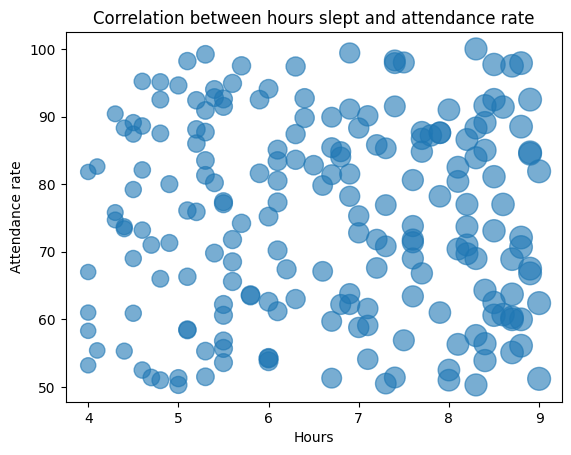

```python
df = pd.read_csv("Dataset5.csv")
plt.scatter(df["sleep_hours"], df["attendance_percent"], s=df["sleep_hours"]*30, alpha=0.6)
plt.xlabel("Hours")
plt.ylabel("Attendance rate")
plt.title("Correlation between hours slept and attendance rate")
plt.show()
```

Based on this scattered chart I can claim that more hours of sleep will slightly lead to better score.

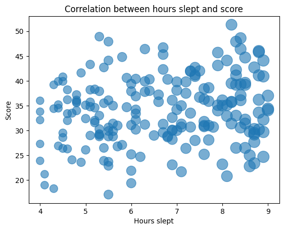

```python
df = pd.read_csv("Dataset5.csv")
plt.scatter(df["sleep_hours"], df["exam_score"], s=df["sleep_hours"]*30, alpha=0.6)
plt.xlabel("Hours slept")
plt.ylabel("Score")
plt.title("Correlation between hours slept and score")
plt.show()
```